# Testing atlantisom: generate census length and age comps from Northeast US Atlantis

Sarah Gaichas and Christine Stawitz

06 May, 2019

## Introduction

This page has visualizations for the NEUS model example, test03032016 (note! a not fully calibrated model). For full explanation of methods, see the file linked at the beginning of each section.

## Simulate a survey part 3: sample for length and age composition

Full methods are explained [here](https://sgaichas.github.io/poseidon-dev/TrueLengthAgeCompTest.html).

The following settings should achieve a survey that samples all Atlantis model output timesteps, all fish and shark species, and all model polygons, with perfect efficiency and full selectivity for all ages:

```r
# should return a perfectly scaled survey
effic1 <- data.frame(species=funct.group.names,
                     efficiency=rep(1.0,length(funct.group.names)))

# should return all lengths fully sampled (Atlantis output is 10 age groups per spp)
# BUT CHECK if newer Atlantis models can do age-specific outputs
selex1 <- data.frame(species=rep(funct.group.names, each=10),
                     agecl=rep(c(1:10),length(funct.group.names)),
                     selex=rep(1.0,length(funct.group.names)*10))

# should return all model areas
boxpars <- load_box(d.name, box.file)
boxall <- c(0:(boxpars$nbox - 1))

# these are model specific, generalized above
# if(initCCA) boxall <- c(0:88)
# if(initNEUS) boxall <- c(0:29)
# if(initNOBA) boxall <- c(0:59)

# should return all model output timesteps; need to generalize
# if(initCCA) timeall <- c(0:100)
# if(initNEUS) timeall <- c(0:251)
# if(initNOBA) timeall <- c(0:560)

# generalized
runpar <- load_runprm(d.name, run.prm.file)
noutsteps <- runpar$tstop/runpar$outputstep
stepperyr <- if(runpar$outputstepunit=="days") 365/runpar$toutinc

timeall <- c(0:noutsteps)

# define set of species we expect surveys to sample (e.g. fish only? vertebrates?)
# for ecosystem indicator work test all species, e.g.
survspp <- funct.group.names

# to keep plots simpler, currently hardcoded for vertebrate/fished invert groups
# if(initCCA) survspp <- funct.group.names[c(1:44, 59:61, 65:68)]
# if(initNEUS) survspp <- funct.group.names[1:21]
# if(initNOBA) survspp <- funct.group.names[1:36]

# for length and age groups lets just do fish and sharks
# NOBA model has InvertType, changed to GroupType in file, but check Atlantis default
if(initNOBA) funct.groups <- rename(funct.groups, GroupType = InvertType)

survspp <- funct.groups$Name[funct.groups$IsTurnedOn==1 &
                           funct.groups$GroupType %in% c("FISH", "SHARK")]

#if(initCCA) survspp <- survspp[!survspp %in% "Pisciv_T_Fish"]
```

Here we use `create_survey` on the numbers output of `run_truth` to create the survey census of age and length composition.

Next, get true annual (cohort) age comp from this census survey based on run truth. (is there a standard Atlantis output I can compare this to as we did for biomass?)

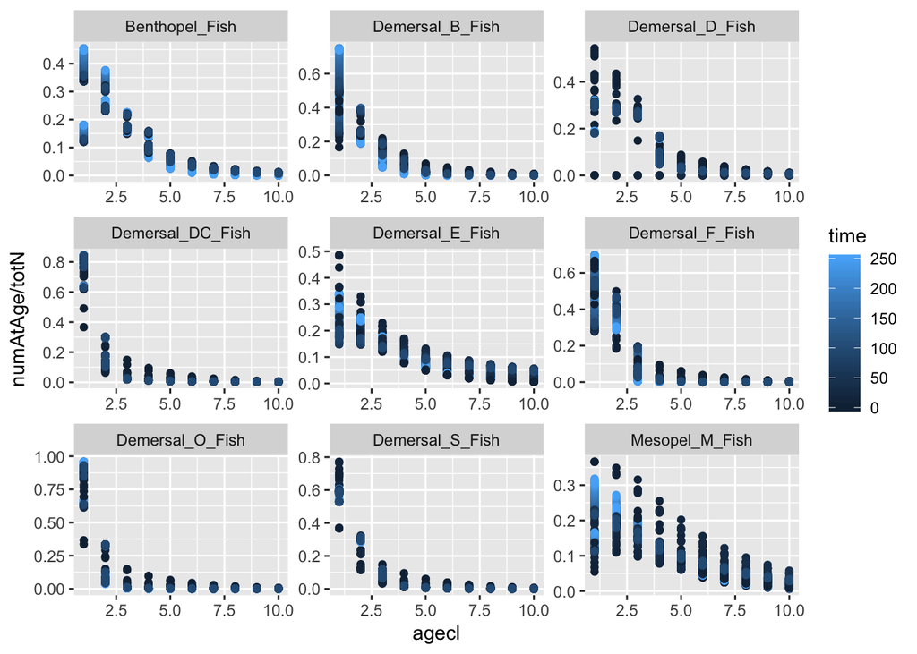

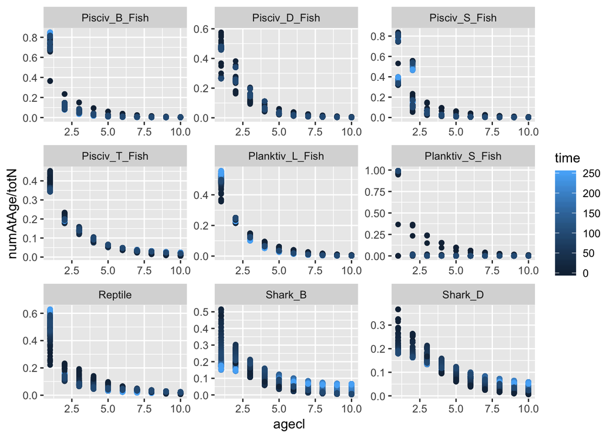

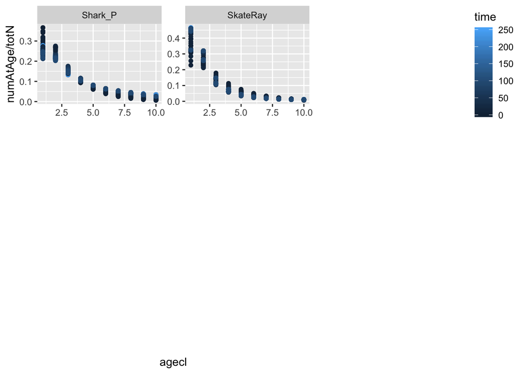

Then we use the `sample_fish` function and compare to true annual age comp calculated above as a test. These should match. We show compositions sampled for the initial time step, a time step in the middle of the run, and the last timestep.

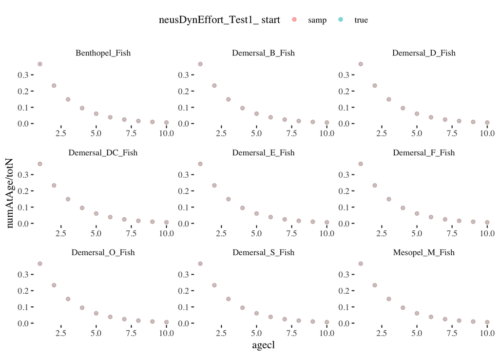

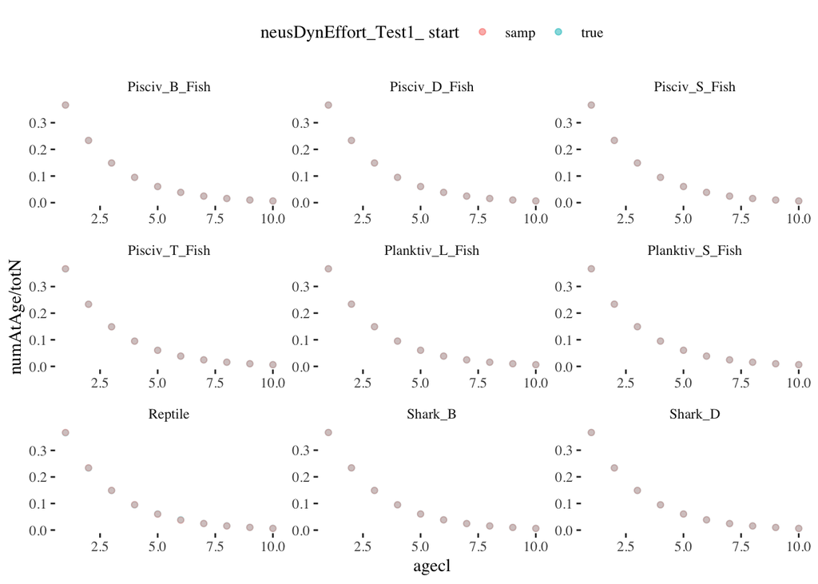

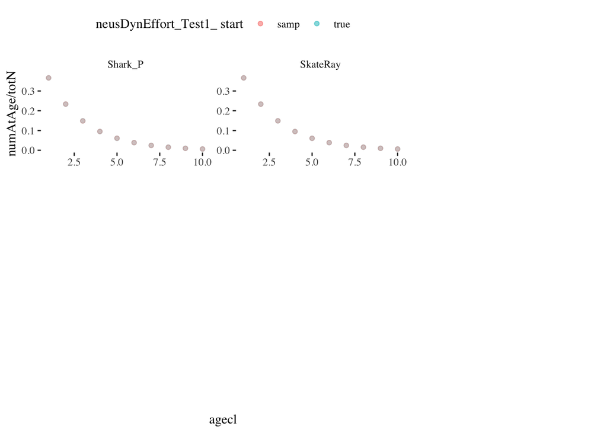

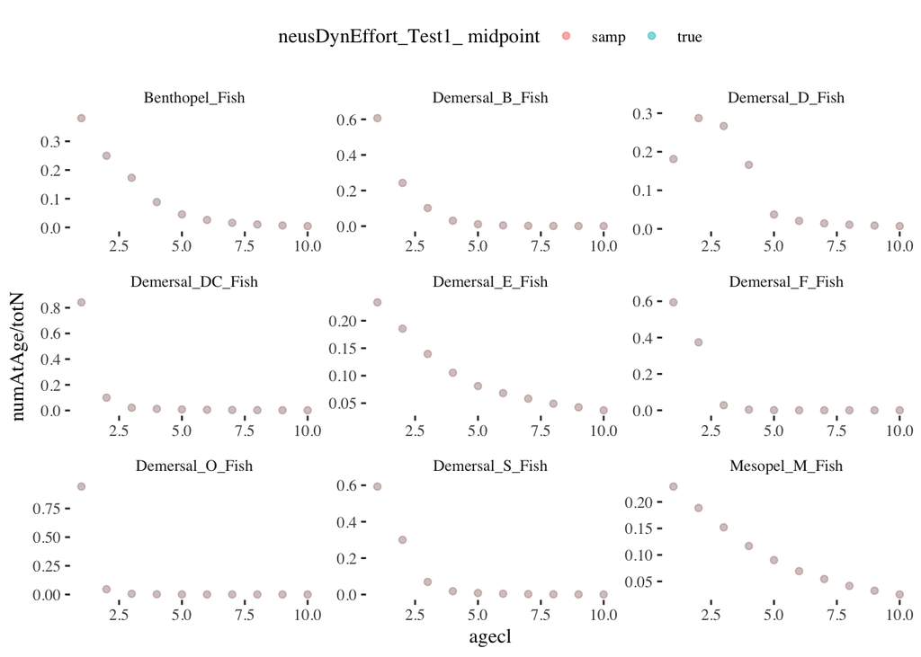

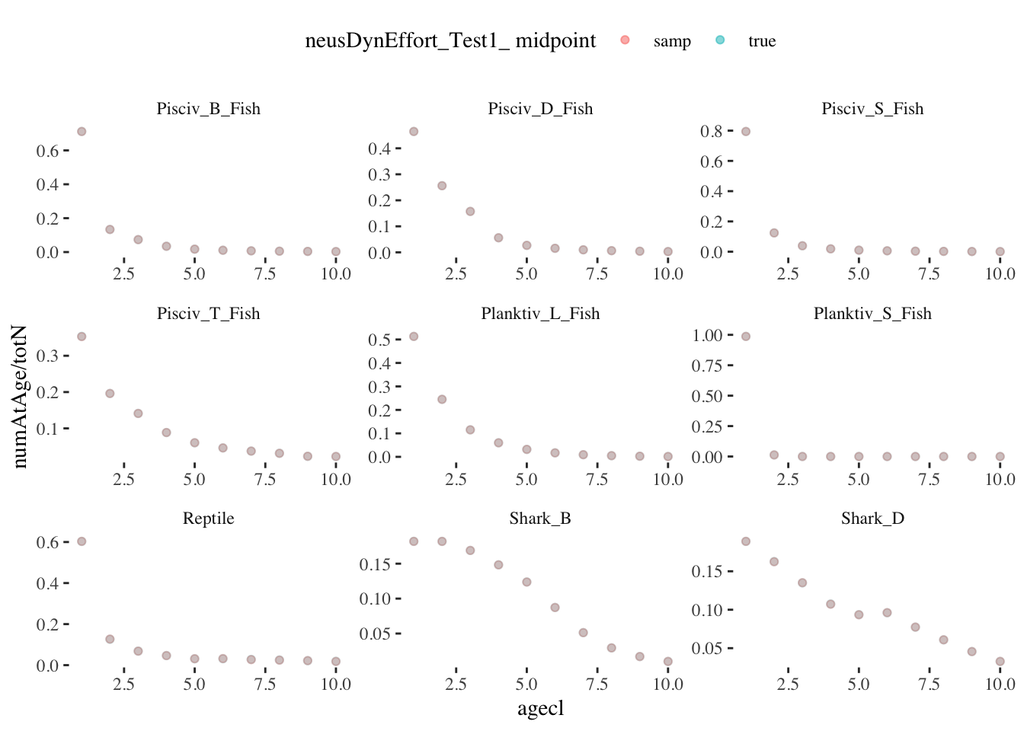

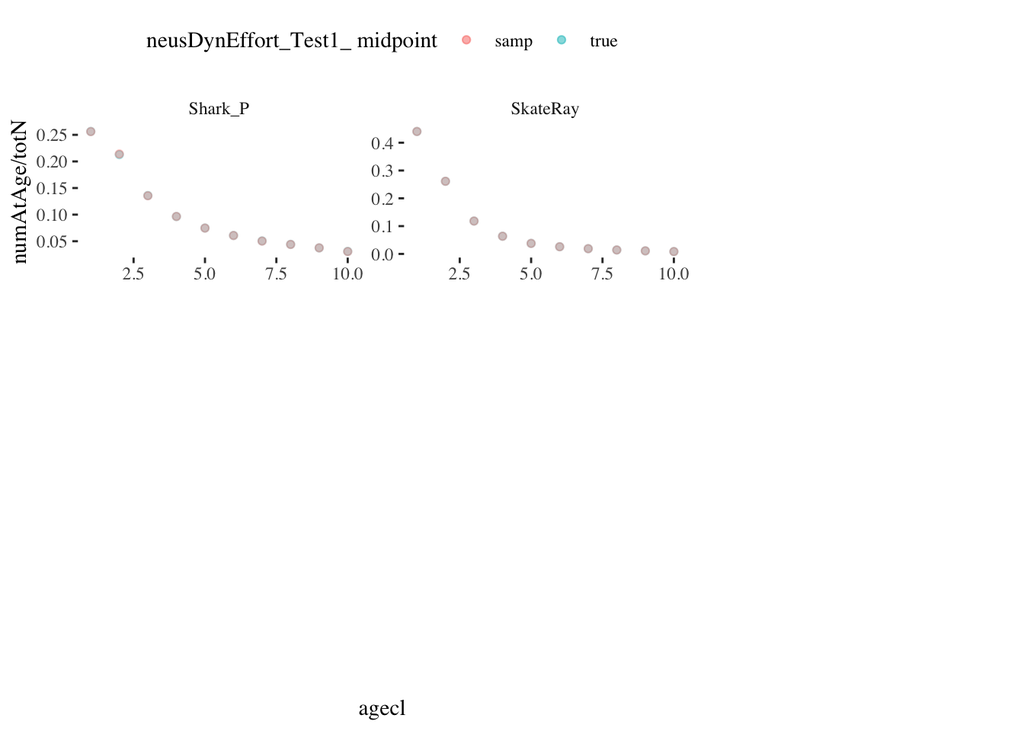

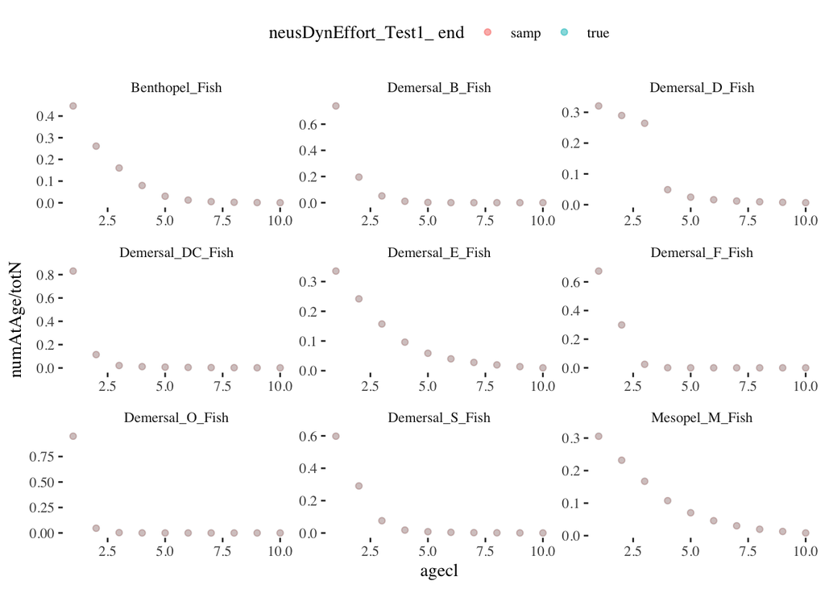

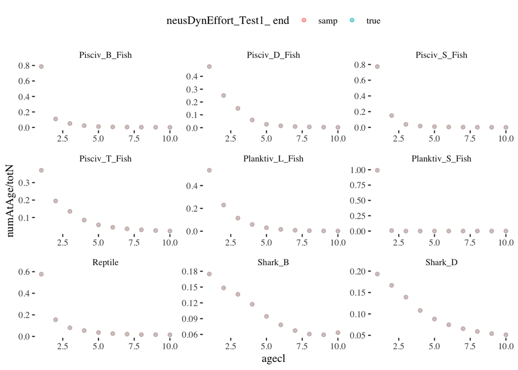

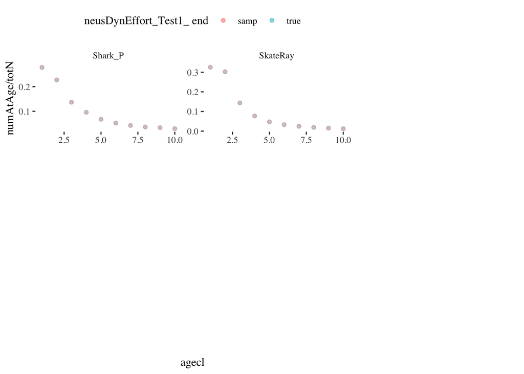

Most match, with some exceptions to be discussed with the regional model developers. NEUS run looks good here.